# Model Selection & Model Performance

### 10.6.6 Visualisation - 0.3

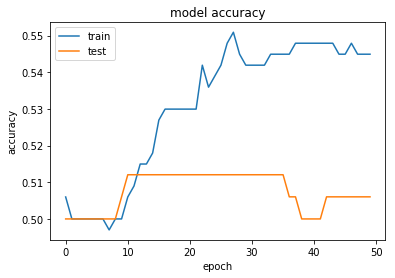

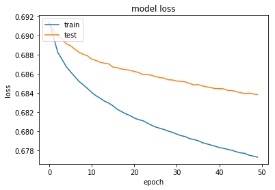

```python
plt.plot(decay_03.history['acc'])
plt.plot(decay_03.history['val_acc'])
plt.title('model accuracy')
plt.ylabel('accuracy')
plt.xlabel('epoch')
plt.legend(['train', 'test'], loc='upper left')
plt.show()

plt.plot(decay_03.history['loss'])
plt.plot(decay_03.history['val_loss'])
plt.title('model loss')
plt.ylabel('loss')
plt.xlabel('epoch')
plt.legend(['train', 'test'], loc='upper left')
plt.show()
```

### 10.6.7 Visualisation - 0.4

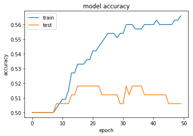

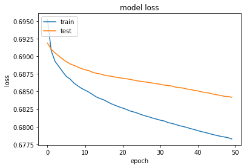

```python
plt.plot(decay_04.history['acc'])
plt.plot(decay_04.history['val_acc'])
plt.title('model accuracy')
plt.ylabel('accuracy')
plt.xlabel('epoch')
plt.legend(['train', 'test'], loc='upper left')
plt.show()

plt.plot(decay_04.history['loss'])
plt.plot(decay_04.history['val_loss'])
plt.title('model loss')
plt.ylabel('loss')
plt.xlabel('epoch')
plt.legend(['train', 'test'], loc='upper left')
plt.show()
```

### 10.6.8 Visualisation - 0.5

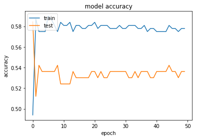

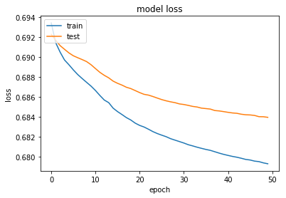

```python
plt.plot(decay_05.history['acc'])
plt.plot(decay_05.history['val_acc'])
plt.title('model accuracy')
plt.ylabel('accuracy')
plt.xlabel('epoch')
plt.legend(['train', 'test'], loc='upper left')
plt.show()

plt.plot(decay_05.history['loss'])
plt.plot(decay_05.history['val_loss'])
plt.title('model loss')
plt.ylabel('loss')
plt.xlabel('epoch')
plt.legend(['train', 'test'], loc='upper left')
plt.show()
```

### 10.6.8 Visualisation - 0.9

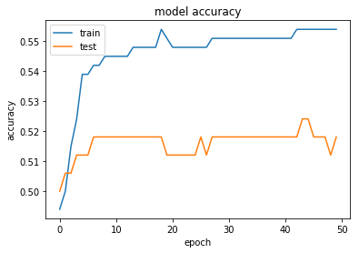

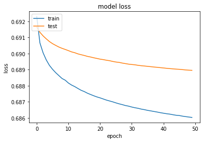

```python
plt.plot(decay_09.history['acc'])
plt.plot(decay_09.history['val_acc'])
plt.title('model accuracy')
plt.ylabel('accuracy')
plt.xlabel('epoch')
plt.legend(['train', 'test'], loc='upper left')
plt.show()

plt.plot(decay_09.history['loss'])
plt.plot(decay_09.history['val_loss'])
plt.title('model loss')
plt.ylabel('loss')
plt.xlabel('epoch')
plt.legend(['train', 'test'], loc='upper left')
plt.show()
```

### 10.6.9 Sub-plot the Results

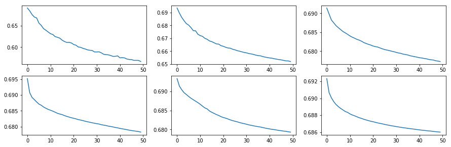

```python
fig = plt.figure(figsize=(15,15))

plt.subplot(6, 3, 1)
plt.plot(decay_01.history['loss'])

plt.subplot(6, 3, 2)
plt.plot(decay_02.history['loss'])

plt.subplot(6, 3, 3)
plt.plot(decay_03.history['loss'])

plt.subplot(6, 3, 4)
plt.plot(decay_04.history['loss'])

plt.subplot(6, 3, 5)
plt.plot(decay_05.history['loss'])

plt.subplot(6, 3, 6)
plt.plot(decay_09.history['loss'])
```

# 11. Weight Initializers

The weight initializers control teh value for which the weights of the model will be set. To find the best recorded initializers that would be placed on each layer (Convolutional and Dense). I tested all initializers that where listed o Keras.io and recorded the 2 best preforming initializers that would be used for grid search. After the tests were completed it was discovered that both Normal and Glorot Uniform where the best preforming initializers.

## 11.1 Uniform

### 11.1.1 Create the Model

```python
model = Sequential()

model.add(Conv2D(16, (3,3), dilation_rate=2, strides=1, kernel_initializer='he_uniform', input_shape = X.shape[1:]))
model.add(Activation("relu"))
model.add(MaxPooling2D(pool_size=(2,2), padding="same"))

model.add(Conv2D(32, (3,3), dilation_rate=2, strides=1, kernel_initializer='he_uniform'))
model.add(Activation("relu"))
model.add(MaxPooling2D(pool_size=(2,2), padding="same"))

model.add(Conv2D(64, (3,3), dilation_rate=2, strides=1, kernel_initializer='he_uniform'))
model.add(Activation("relu"))
model.add(MaxPooling2D(pool_size=(2,2), padding="same"))

model.add(Conv2D(128, (3,3), dilation_rate=2, strides=1, kernel_initializer='he_uniform'))
model.add(Activation("relu"))
model.add(MaxPooling2D(pool_size=(2,2), padding="same"))

model.add(Flatten())
model.add(Dense(32, kernel_initializer='he_uniform'))
model.add(Activation("relu"))

model.add(Dense(64, kernel_initializer='he_uniform'))
model.add(Activation("relu"))

model.add(Dense(1))
model.add(Activation("sigmoid"))

model.compile(loss="binary_crossentropy",
             optimizer="Adam",
             metrics=['accuracy'])
```

### 11.1.2 Fit the Model

```python
init_08 = model.fit(X, y, batch_size=16, epochs=50, validation_split=0.33)
```

```
Train on 334 samples, validate on 166 samples
```

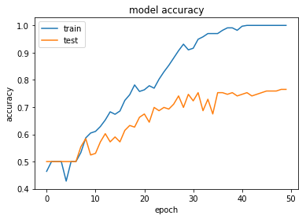

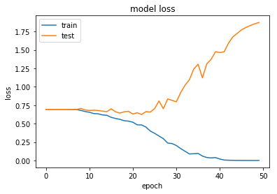

```python
plt.plot(init_01.history['acc'])
plt.plot(init_01.history['val_acc'])
plt.title('model accuracy')
plt.ylabel('accuracy')
plt.xlabel('epoch')
plt.legend(['train', 'test'], loc='upper left')
plt.show()

plt.plot(init_01.history['loss'])
plt.plot(init_01.history['val_loss'])
plt.title('model loss')
plt.ylabel('loss')
plt.xlabel('epoch')
plt.legend(['train', 'test'], loc='upper left')
plt.show()
```

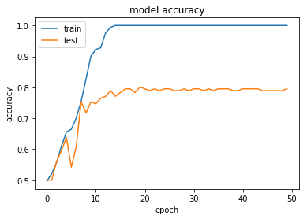

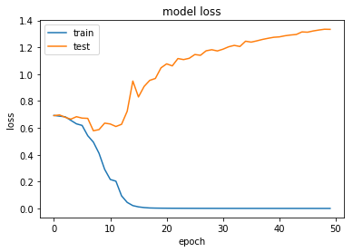

```python
plt.plot(init_02.history['acc'])
plt.plot(init_02.history['val_acc'])
plt.title('model accuracy')
plt.ylabel('accuracy')
plt.xlabel('epoch')
plt.legend(['train', 'test'], loc='upper left')
plt.show()

plt.plot(init_02.history['loss'])
plt.plot(init_02.history['val_loss'])
plt.title('model loss')
plt.ylabel('loss')
plt.xlabel('epoch')
plt.legend(['train', 'test'], loc='upper left')
plt.show()
```

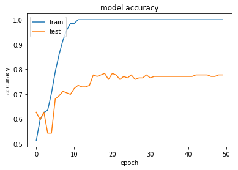

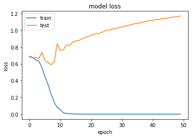

```python
plt.plot(init_03.history['acc'])
plt.plot(init_03.history['val_acc'])
plt.title('model accuracy')
plt.ylabel('accuracy')
plt.xlabel('epoch')
plt.legend(['train', 'test'], loc='upper left')
plt.show()

plt.plot(init_03.history['loss'])
plt.plot(init_03.history['val_loss'])
plt.title('model loss')
plt.ylabel('loss')
plt.xlabel('epoch')
plt.legend(['train', 'test'], loc='upper left')
plt.show()
```

### 11.1.3 Visualisation - "Normal" 0.81% Accuracy

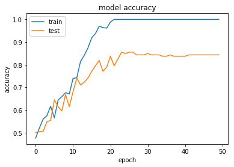

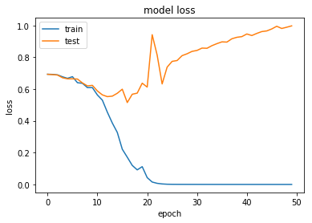

```python
plt.plot(init_04.history['acc'])
plt.plot(init_04.history['val_acc'])
plt.title('model accuracy')
plt.ylabel('accuracy')
plt.xlabel('epoch')
plt.legend(['train', 'test'], loc='upper left')
plt.show()

plt.plot(init_04.history['loss'])
plt.plot(init_04.history['val_loss'])
plt.title('model loss')
plt.ylabel('loss')
plt.xlabel('epoch')
plt.legend(['train', 'test'], loc='upper left')
plt.show()
```

### 11.1.3 Visualisation - "Zero" 0.49% Accuracy

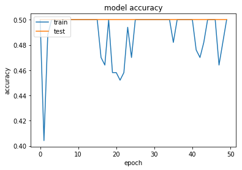

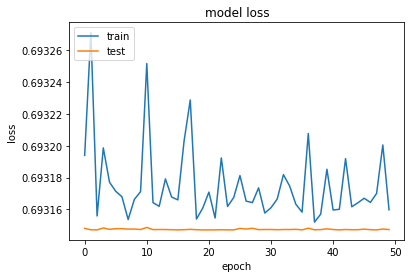

```python
plt.plot(init_05.history['acc'])
plt.plot(init_05.history['val_acc'])
plt.title('model accuracy')
plt.ylabel('accuracy')
plt.xlabel('epoch')
plt.legend(['train', 'test'], loc='upper left')
plt.show()

plt.plot(init_05.history['loss'])
plt.plot(init_05.history['val_loss'])
plt.title('model loss')
plt.ylabel('loss')
plt.xlabel('epoch')
plt.legend(['train', 'test'], loc='upper left')
plt.show()
```

### 11.1.3 Visualisation - "glorot_uniform" 0.80% Accuracy

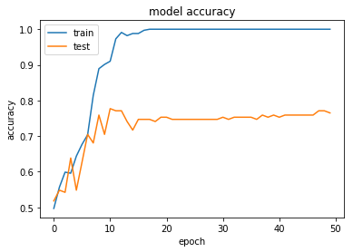

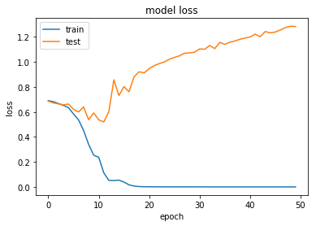

```python
plt.plot(init_06.history['acc'])
plt.plot(init_06.history['val_acc'])
plt.title('model accuracy')
plt.ylabel('accuracy')
plt.xlabel('epoch')
plt.legend(['train', 'test'], loc='upper left')
plt.show()

plt.plot(init_06.history['loss'])
plt.plot(init_06.history['val_loss'])
plt.title('model loss')
plt.ylabel('loss')
plt.xlabel('epoch')
plt.legend(['train', 'test'], loc='upper left')
plt.show()
```

### 11.1.3 Visualisation - "he_normal" 0.72% Accuracy

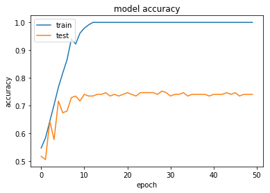

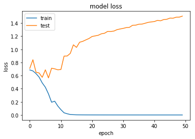

```python
plt.plot(init_07.history['acc'])
plt.plot(init_07.history['val_acc'])
plt.title('model accuracy')
plt.ylabel('accuracy')
plt.xlabel('epoch')
plt.legend(['train', 'test'], loc='upper left')
plt.show()

plt.plot(init_07.history['loss'])
plt.plot(init_07.history['val_loss'])
plt.title('model loss')
plt.ylabel('loss')
plt.xlabel('epoch')
plt.legend(['train', 'test'], loc='upper left')
plt.show()
```

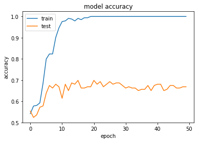

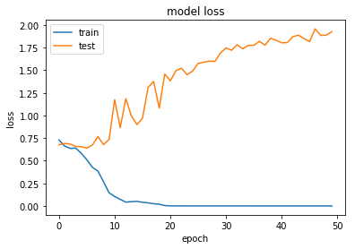

```python
plt.plot(init_08.history['acc'])
plt.plot(init_08.history['val_acc'])
plt.title('model accuracy')
plt.ylabel('accuracy')
plt.xlabel('epoch')
plt.legend(['train', 'test'], loc='upper left')
plt.show()

plt.plot(init_08.history['loss'])
plt.plot(init_08.history['val_loss'])
plt.title('model loss')
plt.ylabel('loss')
plt.xlabel('epoch')
plt.legend(['train', 'test'], loc='upper left')
plt.show()
```

# 12. Batch Size & Epoch Range Investigation

The batch size and epoch range are the final two hyper-parameters that will be used during grid search. My analysis of the batch size discovered that using a small batch size of ranges 32-64 worked the best when the epoch range was between 50-100. As the batch size increased the model would no longer converge and would need an increase in the epoch range to acheive convergence. This why I chose these ranges as the values I would use in my process of grid search which would scan the model and discover the best preforming model.

## 12.1 Batch Size

### 12.1.1 Create the Model

```python
model = Sequential()

model.add(Conv2D(16, (3,3), dilation_rate=2, strides=1, input_shape = X.shape[1:]))
model.add(Activation("relu"))
model.add(MaxPooling2D(pool_size=(2,2), padding="same"))

model.add(Conv2D(32, (3,3), dilation_rate=2, strides=1))
model.add(Activation("relu"))
model.add(MaxPooling2D(pool_size=(2,2), padding="same"))

model.add(Conv2D(64, (3,3), dilation_rate=2, strides=1))
model.add(Activation("relu"))
model.add(MaxPooling2D(pool_size=(2,2), padding="same"))

model.add(Conv2D(128, (3,3), dilation_rate=2, strides=1))
model.add(Activation("relu"))
model.add(MaxPooling2D(pool_size=(2,2), padding="same"))

model.add(Flatten())
model.add(Dense(128))
model.add(Activation("relu"))

model.add(Dense(64))
model.add(Activation("relu"))

model.add(Dense(32))
model.add(Activation("relu"))

model.add(Dense(1))
model.add(Activation("sigmoid"))

model.compile(loss="binary_crossentropy",
             optimizer="Adam",
             metrics=['accuracy'])
```

### 12.1.2 Fit the Model

```python
batch_32 = model.fit(X, y, batch_size=32, epochs=50, validation_split=0.33)
```

```
Train on 334 samples, validate on 166 samples
```

### 12.1.3 Visualise the Results

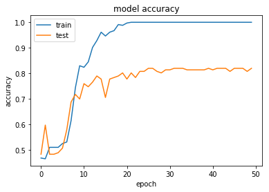

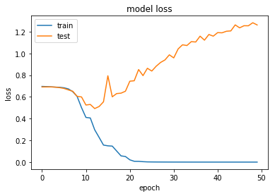

```python
plt.plot(batch_32.history['acc'])
plt.plot(batch_32.history['val_acc'])
plt.title('model accuracy')
plt.ylabel('accuracy')
plt.xlabel('epoch')
plt.legend(['train', 'test'], loc='upper left')
plt.show()

plt.plot(batch_32.history['loss'])
plt.plot(batch_32.history['val_loss'])
plt.title('model loss')
plt.ylabel('loss')
plt.xlabel('epoch')
plt.legend(['train', 'test'], loc='upper left')
plt.show()
```

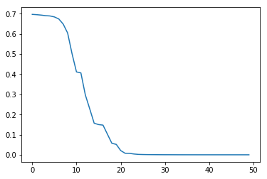

```python
plt.plot(batch_32.history['loss'])
plt.show()
```

### 12.1.4 Sub-plot the Results - Batch Size

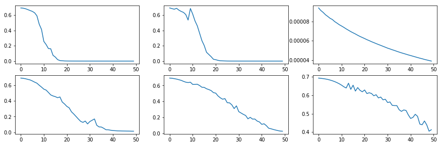

```python
fig = plt.figure(figsize=(15,15))

plt.subplot(6, 3, 1)
plt.plot(batch_16.history['loss'])

plt.subplot(6, 3, 2)
plt.plot(batch_32.history['loss'])

plt.subplot(6, 3, 3)
plt.plot(batch_64.history['loss'])

plt.subplot(6, 3, 4)
plt.plot(batch_128.history['loss'])

plt.subplot(6, 3, 5)
plt.plot(batch_256.history['loss'])

plt.subplot(6, 3, 6)
plt.plot(batch_512.history['loss'])
```

### 12.1.5 Sub-plot the Results - Epoch Range

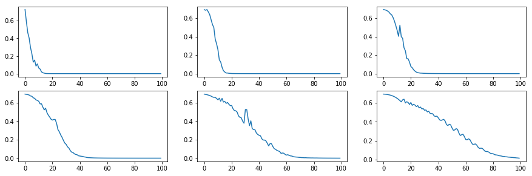

```python
fig = plt.figure(figsize=(15,15))

plt.subplot(6, 3, 1)
plt.plot(batch_16_100.history['loss'])

plt.subplot(6, 3, 2)
plt.plot(batch_32_100.history['loss'])

plt.subplot(6, 3, 3)
plt.plot(batch_64_100.history['loss'])

plt.subplot(6, 3, 4)
plt.plot(batch_128_100.history['loss'])

plt.subplot(6, 3, 5)
plt.plot(batch_256_100.history['loss'])

plt.subplot(6, 3, 6)
plt.plot(batch_512_100.history['loss'])
```

# 13. Final Model

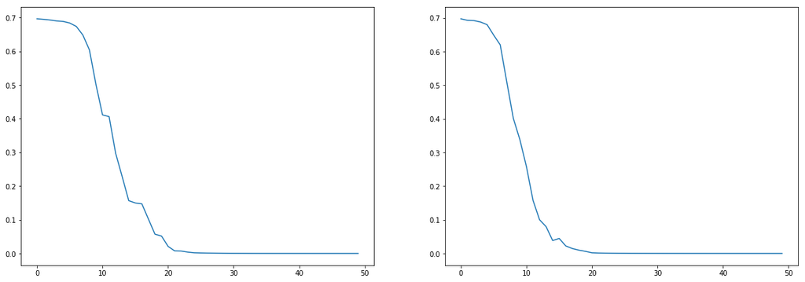

```python
fig = plt.figure(figsize=(20,15))

plt.subplot(2, 2, 1)
plt.plot(batch_32.history['loss'])

plt.subplot(2, 2, 2)
plt.plot(model4_01.history['loss'])
```